# Workshop 8: Introduction to GGPLOT

Cassandra Buzby & Yen-Chung Chen

7/15/2021

# Review

## Loading In Data

Your own data is not already in R! This is where working directories come back into play. To load in a file, you can use read.csv() or read.table(), which each take in your file name and arguments that tell R how to format your data into a data frame.

Load in penguins.csv from the website (it will probably be in your downloads folder) and **save it as a variable**. Without saving to a variable, read.csv() will print the entire dataset into your workspace without saving.

```r
penguins <- read.csv("penguins.csv", row.names = 1)

head(penguins)
```

```
##   species    island bill_length_mm bill_depth_mm flipper_length_mm body_mass_g
## 1  Adelie Torgersen           39.1          18.7               181        3750
## 2  Adelie Torgersen           39.5          17.4               186        3800
## 3  Adelie Torgersen           40.3          18.0               195        3250
## 4  Adelie Torgersen             NA            NA                NA          NA
## 5  Adelie Torgersen           36.7          19.3               193        3450
## 6  Adelie Torgersen           39.3          20.6               190        3650
##      sex year
## 1   male 2007
## 2 female 2007
## 3 female 2007
## 4   <NA> 2007
## 5 female 2007
## 6   male 2007
```

## Your Own Data!

Choose your own data to load into your workspace, and save it as a variable. Next, we will be exploring this data as a data frame. This should be saved as a .csv (or .tsv) on your computer. We will then be answering questions about this dataset

```r
#1. Load in your data and save as a variable. Determine based on YOUR data if you should include headers and row numbers.

#2. How many rows of data to you have?

#3. How many columns of data do you have?

#4. What data types are each of your columns?

#5. What is the mean of your first numeric column?
```

## A Few New Functions

For the next exercises, it might be helpful to look into the following functions:

```r
unique(penguins$species)
```

```
## [1] "Adelie"    "Gentoo"    "Chinstrap"
```

```r
table(penguins$island)
```

```
##
##    Biscoe     Dream Torgersen
##       168       124        52
```

```r
#when using sum() or mean(), set na.rm = TRUE
```

## Review Exercise

With your partner, pick two of the following tasks that you have not already solved to complete:

```r
# 1. Which species of penguin has the largest average bill length? Which species has the smallest bill depth?
```

```r
# 2. Make a new data frame including the smallest 10% of flipper lengths and count how many penguins of each species are represented.
```

```r
# 3. Is the sampling between islands consistent? How many penguins of each species were sampled from each island?
```

```r
# 4. Was the sampling by sex equal each year? How many of the penguins were female each year compared to males?
```

# Plotting data with ggplot!

One of the best ways to visualize data is ggplot! Ggplot is a package which takes long data and makes beautiful plots. This package needs to be installed, which can be done using install.package. Don’t forget that **after you install, you must load the package into your workspace** for it to be active.

```r
#install.packages(ggplot2)
library(ggplot2)
```

The function of ggplot is generally as shown below, with ggplot() indicating the data and geom_point() indicating a scatter plot. Then, each of the arguments to be plotted are defined within data or aes, which are either arguments or functions themselves.

The **plus sign (+)** connects ggplot() to geom_point(), which indicates that R should run both together.

### Scatter Plot

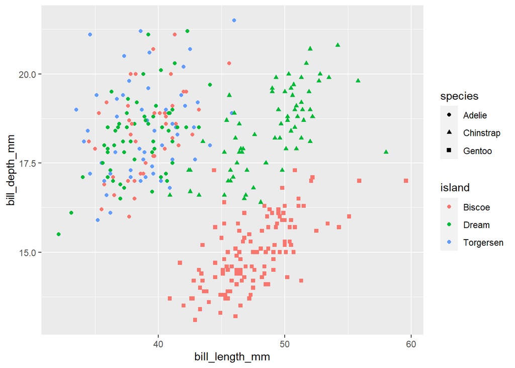

```r
ggplot(data = penguins, aes(x = bill_length_mm,
                            y = bill_depth_mm,
                            color = island,
                            shape = species)) + geom_point()
```

### Density Plots and Themes

Ggplot can also take in themes, many of which are built in. The sizes, shapes, colors, fonts, and many other things can be indicated as well:

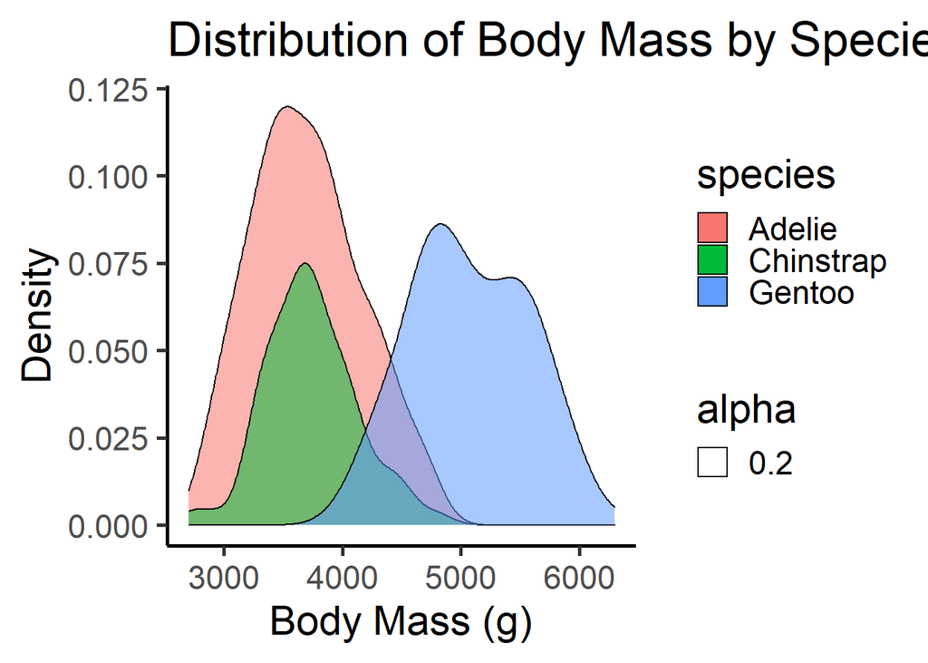

```r
ggplot(penguins, aes(body_mass_g,
                     y=..count..,
                     fill = species,
                     alpha = 0.2)) +
  geom_density() +
  ggtitle("Distribution of Body Mass by Species") +
  xlab("Body Mass (g)") + ylab("Density") +
  theme_classic(base_size = 22)
```

### Boxplots

Another type of plot is a box plot, which can show the distributions of each category. Since each plot takes in different arguments, it’s important to understand what your data looks like as well as what geom you’re using.

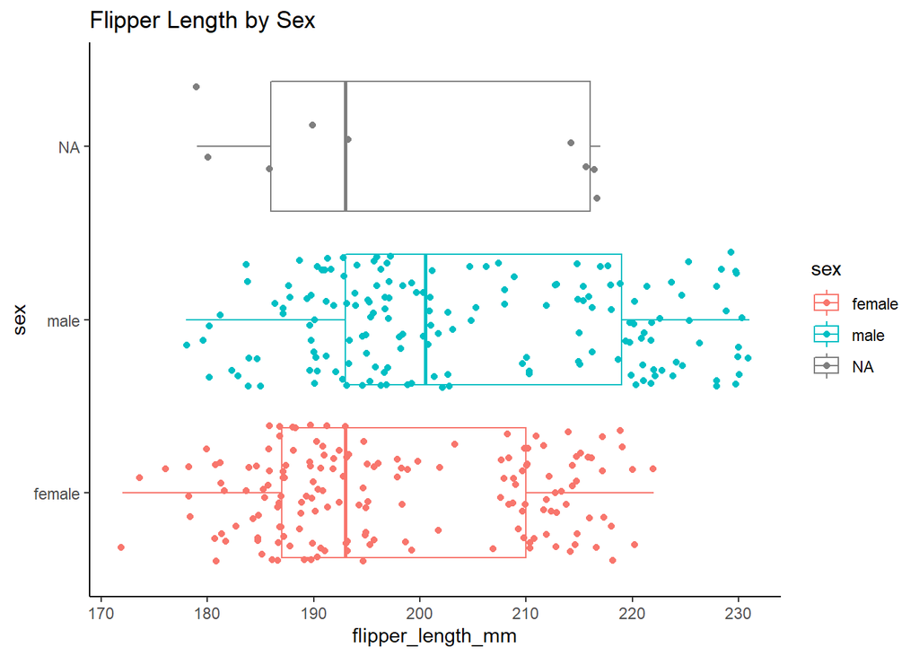

```r
ggplot(penguins,
       aes(x = flipper_length_mm, group = sex, y = sex, color = sex)) +
  geom_boxplot() +
  geom_jitter() +
  ggtitle("Flipper Length by Sex") +
  theme_classic()
```

### Removing NAs

Notice that we have NAs in this dataset! How do we want to remove them?

You can use a function called ‘subset()’ to remove NAs from a specific column, in this case the sex.

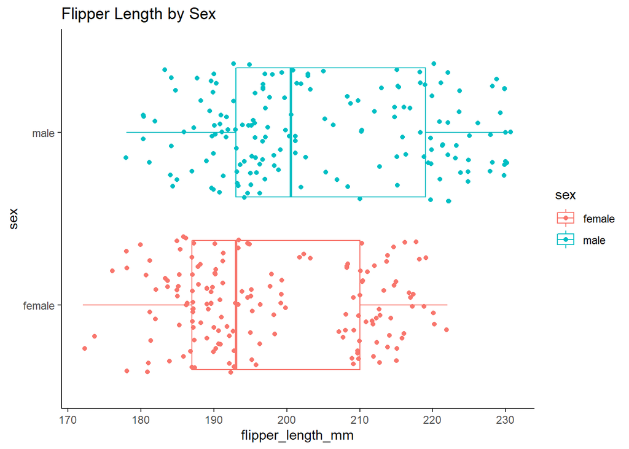

```r
ggplot(data=subset(penguins, !is.na(sex)),
       aes(x = flipper_length_mm, group = sex, y = sex, color = sex, na.rm = TRUE)) +
  geom_boxplot(na.rm = TRUE) +
  geom_jitter(na.rm = TRUE) +
  ggtitle("Flipper Length by Sex") +
  theme_classic()
```

### Types of geoms

We’ve so far covered scatter plots, density plots, and boxplots. But there are other geoms that we can use depending on what type of data we have:

- scatter plots: geom_point()
- density plots: geom_density()
- histograms: geom_histogram()
- boxplots: geom_boxplot()
- barplots: geom_bar()
- lineplots: geom_line()

### Modifying **geom** properties

We can also pass additional arguments to the geom: useful ones to know are:

- **color**: line color; for the default shape used in geom_point, this actually colors the inside of the shape as well
- **fill**: the fill color inside a shape
- **size**: point size or line thickness
- **shape**: for points, this is the shape; for lines, this is the line pattern or dashyness
- **alpha**: transparency level, with 0 being totally transparent and 1 being a solid, opaque color

## Practice Plotting

```r
# Try making a scatter plot of two numeric variables from penguins and coloring by a categorical variable.

# What does this show you?
```

## Plotting your own data

In pairs, discuss what might be a useful comparison in your data, and how ggplot() might help to display this.

```r
#1. Check to make sure that your data from before is loaded in as a single csv which contains rows and columns that can be used for analysis

#2. Reformat your data to long form (ie, one row for every observation, columns for every characteristic)

#3. Choose ONE ggplot item to plot:
```

# Functions

The three main parts of a function are (1) the **input**, (2) the action itself, and (3) the **output**. To better understand these elements, we are going to build our own function.

```r
myfunction <- function(x){x+2}
```

We can use this function by running:

```r
myfunction(12)
```

```
## [1] 14
```

## Build Your Own Function!

Let’s build a function that returns an encouraging statement. We can use the function sample() to randomly choose a compliment from a vector of strings. Let’s first make the vector of strings:

```r
a <- "You're doing great!"
b <- "Research is hard, but perserverence is the key to success"
c <- "I'm glad to see you here today"

compliments <- c(a,b,c)
```

Next, we want to sample from these compliments

```r
sample(compliments, 1)
```

```
## [1] "Research is hard, but perserverence is the key to success"
```

Finally, we’ll want a function to give a random compliment every time the function is used. Let’s name this function “complimentme” and have it not require any input:

```r
complimentme <- function(){
  a <- "You're doing great!"
  b <- "You are doing awesome science"
  c <- "I'm glad to see you here today"

  compliments <- c(a,b,c)
  return(sample(compliments, 1))
}
```

```r
complimentme()
```

```
## [1] "You are doing awesome science"
```

How would you add an input of telling R how many compliments to give you?

```r
# Change the complimentme() function to return a user-defined number of compliments
```